# Final Report

Jordan KongQuee

April 23, 2020

# Introduction

This report details the findings of an analysis of police arrests in Chapel Hill between January 1, 2010 and August 26, 2019. Using data publicly available from the Chapel Hill Police Department, obtained via the Chapel Hill Public Library website, we were able to analyze trends in arrest type, location of arrest, and the demographic information about the arrested individual. Aside from providing interesting information about the nature of arrests in Chapel Hill during the majority of the preceding ten years, the data allows for prediction of the primary charge for which an individual may be arrested, given the arrestee’s age, race, and gender.

This specific project was of interest because the arrest incidents in Chapel Hill directly impact the lives of college students at the University of North Carolina at Chapel Hill, either directly or indirectly. Knowing the nature of arrests in Chapel Hill would be beneficial to these students, as well as to the larger community at UNC. Furthermore, because Chapel Hill is a college town, it was of interest to know if arrests associated with college students, including liquor law violations and noise complaints, were particularly prevalent.

Upon considering the data available, the following questions were identified as capable and worthy of being answered.

1. What are the most frequently observed arrest categories in Chapel Hill in the past decade? Furthermore, for any given arrest, how has the number of that type of arrest per year changed throughout time? What arrest categories are on the rise, on the decline, and staying constant?
2. What is the distribution of arrests throughout the calendar year? Are certain months in the year more prone to arrests? Do arrests, or specific arrests, occur more often on certain days in the year, such as on holidays or during college-celebrated events?
3. Are there associations between types of arrests and the demographic information about the individual arrested? If the age, race, and gender of a person are known, could the person’s most likely arrest category be predicted?
4. Are there areas in Chapel Hill that are more prone to arrests than others? If so, could these areas be classified into distinct clusters?

# Data Description and Exploration

The specific dataset used in this analysis contains records of every arrest in Chapel Hill during the aforementioned time period. For each arrest, the following variables were recorded. See the notes below for a description of each variable.

- Primary charge: the primary charge for which the individual was arrested
- City: the city in which the arrest took place
- State: the state in which the arrest took place
- Date of arrest: the date of the arrest
- Age: the age of the individual arrested
- Race: the race of the individual arrested
- Gender: the gender of the individual arrested
- Ethnicity: the ethnicity of the individual arrested
- Latitude and longitude: the latitude and longitude of the scene of the arrest

To prepare the data for the analytical methods below, several adjustments needed to be made to the dataset. First, the unused variables listed above were removed, and some of the variables that were used were altered. For example, the latitude and longitude variable was separated into two different variables, one for latitude and one for longitude. Similarly, the date of arrest variable was separated into three variables, one each for the month, the day, and the year of the arrest. Additionally, the data types were adjusted accordingly, from numbers to factors in some cases.

Several misspellings of Chapel Hill were present in the city variable, so these misspellings were corrected. Strangely, although the vast majority of the arrests in the dataset were identified as having taken place in Chapel Hill, a handful had other cities listed. For example, the city variable included cities other than Chapel Hill, ranging from Carrboro and Mebane to Greensboro and Charlotte. Some of the cities listed belonged to states other than North Carolina as well, including an arrest in Fairfax, Virginia and one in Conway, South Carolina. The reason that arrests that took place in these disparate cities were included in the Chapel Hill arrest records dataset was not immediately clear. To remove this uncertainty, we deleted all arrests that did not have Chapel Hill listed as the city from the data used in the analysis.

Finally, and most substantively, the category variable was formed using a series of regular expressions applied to the primary charge variable. One such regular expression, used to create the driving violation category, is written below.

```r
#(?<!A)NDL|SPEED|(?<![LO] )(?<!Y OF )LICENSE|(?<!IMPAIRED )(?<!G WHILE )(?!.*(WHILE|AFTER))DRIVING|(?!.*TION)INSURANCE|DWLR|(?<!R )REGISTRATION|REVOK|SEAT BELT|FICT|FLO.*FIC|HIT|ATE.*VEH|IMP REG|ACCIDENT|USE.*ICLE|PASSENGER U|TAMP|LIGHT
```

A subset of the data after the above changes were made appears below.

Chapel Hill Arrests

| Primary Charge | City | State | Year | Month | Day | Age | Race | Gender | Ethnicity | Latitude | Longitude | Category | Date |
| --- | --- | --- | --- | --- | --- | --- | --- | --- | --- | --- | --- | --- | --- |
| ASSAULT-SIMPLE | CHAPEL HILL | NC | 2019 | 8 | 26 | 25 | White | Female | N | 35.94424 | -79.01174 | ASSAULT | 2019-08-26 |
| FAIL TO APPEAR/COMPL | CHAPEL HILL | NC | 2019 | 8 | 26 | 27 | Black | Male | N | 35.91334 | -79.05829 | OTHER | 2019-08-26 |
| PUBLIC URINATION | CHAPEL HILL | NC | 2019 | 8 | 26 | 57 | Black | Male | N | 35.93506 | -79.02194 | OTHER | 2019-08-26 |
| AFFRAY/ASSAULT & BATTERY | CHAPEL HILL | NC | 2019 | 8 | 26 | 55 | Black | Male | N | 35.94424 | -79.01174 | ASSAULT | 2019-08-26 |
| ASSAULT-SIMPLE | CHAPEL HILL | NC | 2019 | 8 | 26 | 21 | White | Female | N | 35.90720 | -79.05723 | ASSAULT | 2019-08-26 |

# Results

This section details the methods and results obtained in an attempt to answer the previously stated questions. Although not all methods were successful, we were nonetheless able to obtain some interesting insights.

#### Question 1

*What are the most frequently observed arrest categories in Chapel Hill in the past decade? Furthermore, for any given arrest, how has the number of that type of arrest per year changed throughout time? What arrest categories are on the rise, on the decline, and staying constant?*

Our first approach to answering this question was to determine the most common primary charge categories, as previously created from the primary charge variable, over all years represented in the dataset. The following table displays the number of instances of arrests in Chapel Hill for each category from January 1, 2010 to August 26, 2019.

Number of Arrests by Category

| Category | Number of Arrests |
| --- | --- |
| OTHER | 3560 |
| LIQUOR LAW VIOLATION | 2917 |
| DWI | 1692 |
| DRUG/NARCOTIC VIOLATION | 1667 |
| ASSAULT | 1526 |
| LARCENY | 1087 |
| TRESPASSING | 740 |
| BURGLARY | 543 |
| DRIVING | 384 |
| STALKING AND THREATS | 270 |
| OTHER FRAUD | 265 |
| VANDALISM AND PROPERTY DAMAGE | 249 |
| ID FRAUD | 195 |
| ILLEGAL WEAPON VIOLATION | 185 |
| PANHANDLING | 110 |
| SEX OFFENSES | 103 |
| NOISE COMPLAINT | 102 |
| ROBBERY | 97 |
| DOMESTIC VIOLENCE | 91 |
| MOTOR VEHICLE THEFT | 51 |
| MURDER AND MANSLAUGHTER | 14 |

The above table displays the total number of arrests for each category regardless of the year in which the arrest took place. We next consider the trend of all arrests throughout time, specifically whether or not arrests have exhibited a rising or falling pattern throughout the past decade. First, because the dataset did not contain a full year’s worth of arrest data for 2019, this year was excluded in the following analyses.

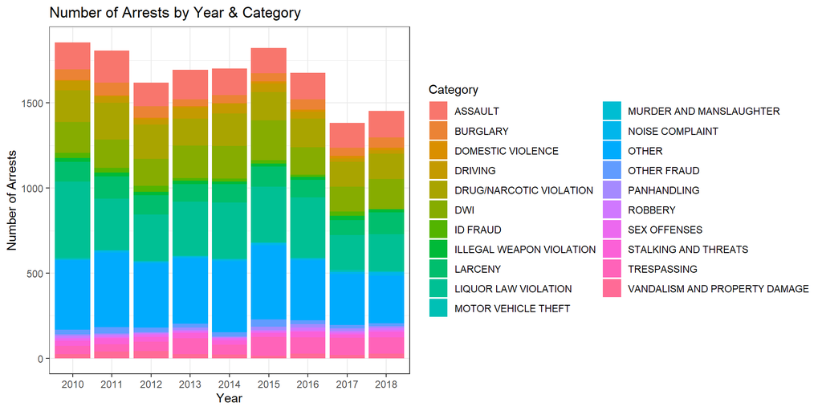

As is evident in the bar chart above, which tracks the number of arrests made as a function of time, 2010, 2011, and 2015 featured larger numbers of arrests, while 2017 and 2018 featured fewer arrests. Although it is difficult to decipher a trend within the nine years in the chart, it is notable that the two years with the fewest recorded arrests were the two most recent years with full data available. Moving into the future, it will be interesting to determine if the annual number of arrests will remain lower than it has been in the past, or if these two years simply represent an anomaly. The bar chart also breaks the total number of arrests in a given year into each of the 21 categories. To better track the occurrence of arrests pertaining to these categories throughout time, we next separate out these categories.

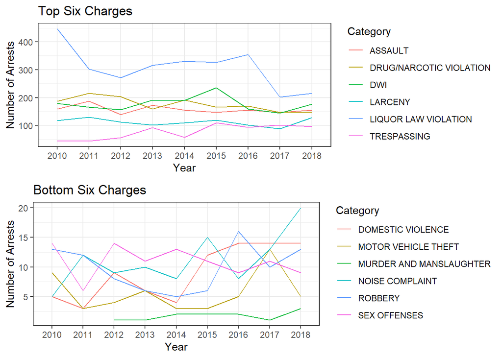

The first chart above depicts the total number of arrests belonging to each of the top six most common arrest categories as a function of time. Each line represents one of the six categories. Although assault, drug and narcotic violation, DWI, larceny, and trespassing arrests remained relatively constant throughout the years, there is an apparent marked decrease in the number of liquor law violation arrests since 2010. In particular, the number of such arrests halved, from around 450 in 2010 to only around 225 in 2018. Between these years, from 2011 through 2016, the number of liquor law violation arrests remained relatively constant, with between roughly 250 and 350 arrests of this type per year. It appears, then, that the dramatic decrease in these arrests in 2017 and 2018 was the leading factor in the overall number of arrests decreasing during these two years, noted above. For any given year, liquor law violations are the most common arrest category, but the relative standing among the other five categories varies, although larceny and trespassing are always the two least common categories from these six. The other three are tightly bunched together.

In summary, the most significant trend between the years 2010 and 2018 was the decline in liquor law violation arrests in 2017 and 2018, which appears to have been the driving factor in the overall decline in arrests for these years. Most other arrest categories remained relatively flat. This same trend was also observed in the middle nine arrest categories, not shown for the sake of avoiding repetition. Aside from these trends, or lack thereof, the most common arrest category by far was liquor law violation arrests, with mostly nonviolent arrest categories rounding out the top six.

#### Question 2

*What is the distribution of arrests throughout the calendar year? Are certain months in the year more prone to arrests? Do arrests, or specific arrests, occur more often on certain days in the year, such as on holidays or during college-celebrated events?*

First, we take a large-scale approach to answering this question, focusing on the number of arrests in each month. The following bar chart shows the total number of arrests across all years for each of the twelve months of the year.

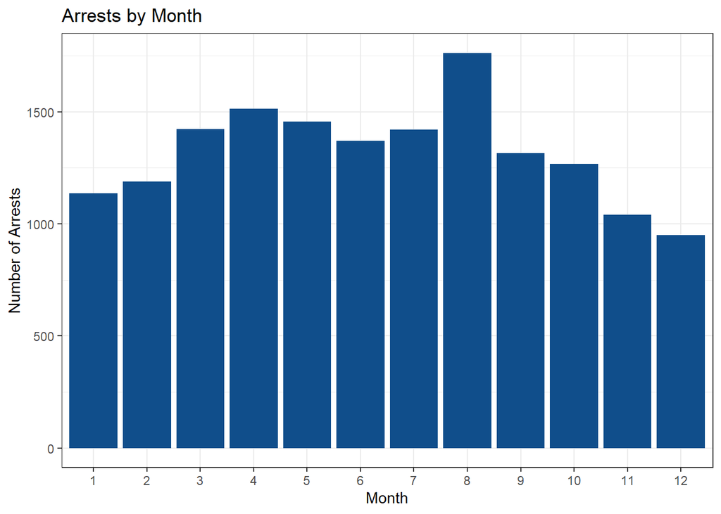

Second, the number of arrests in August is disproportionately high. We look specifically at each day within each month to attempt to provide an explanation for the August anomaly, as well as to identify trends that occur on specific days, such as on holidays, in the year. The series of twelve graphs below depicts the total number of arrests on each day of the year, separated by month. Each month is identified by the number of the month in the calendar year.

##### Breakdown by Month

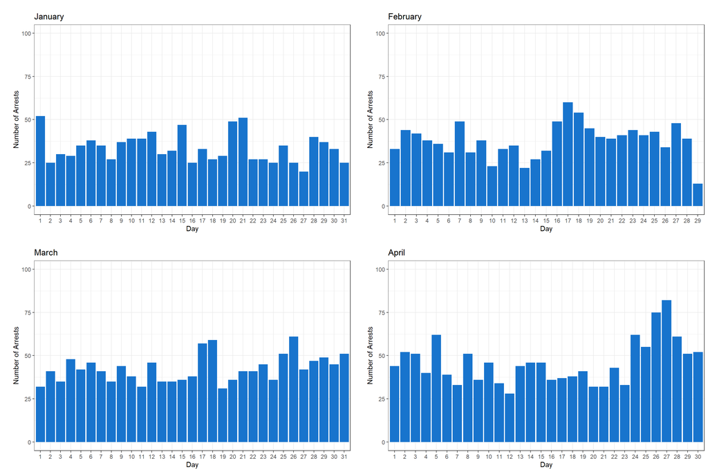

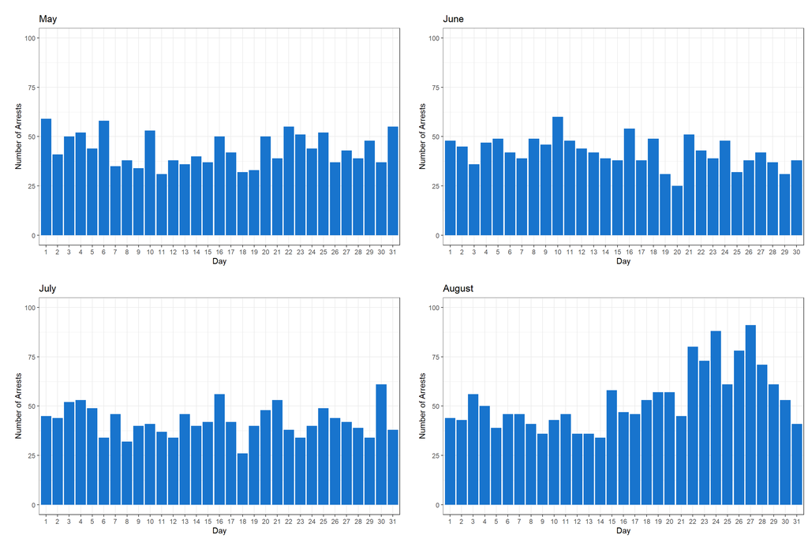

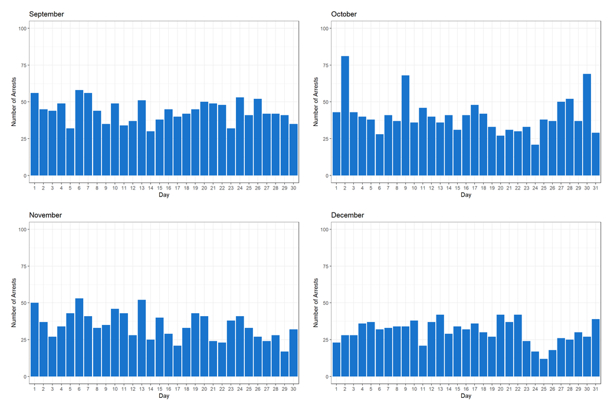

From the above graphs, we can see that the daily number of arrests tends to increase at the end of April and at the end of August. Interestingly, these two time periods represent the end and the beginning of the school year at UNC, respectively. From this observation, it can be surmised that perhaps the arrival and impending departure of students in Chapel Hill leads to an increase in arrests.

With regard to other holidays, New Year’s Day, January 1, is home to the largest number of arrests in the month of January, perhaps a result of increased DWI and other similar arrests related to disorderly conduct and drunkenness. Surprisingly, few arrests occurred on Halloween, but November 1, the following day, is among the top three arrest days in November, perhaps as a result of lingering illegal activity from the previous day. Other holidays, like the Fourth of July, do not stand out from the prevailing monthly trends during the corresponding time of year. The following tables categorize the arrests on Christmas and on New Year’s Day by arrest category. We further wanted to explore our theories as to the types of crimes being committed on these days.

Arrests by Category on Christmas

| Category | Number of Arrests |
| --- | --- |
| DWI | 5 |
| DRUG/NARCOTIC VIOLATION | 4 |
| ASSAULT | 1 |
| BURGLARY | 1 |
| TRESPASSING | 1 |

Arrests by Category on New Year’s Day

[output not shown]

To determine the breakdown of the late April and late August spike in arrests, we next consider the daily number of liquor law violation arrests in isolation for these months. The first two graphs below show daily liquor law arrests for April and August, and the bottom two graphs show all arrests except liquor law arrests.

##### Daily Arrests with Liquor Law

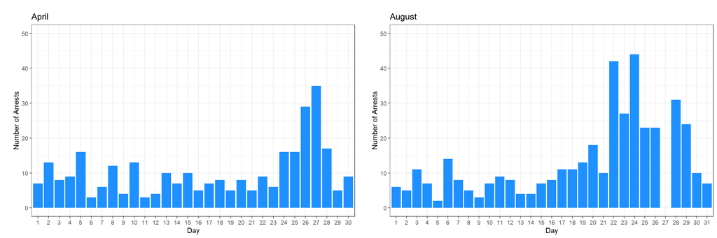

##### Daily Arrests without Liquor Law

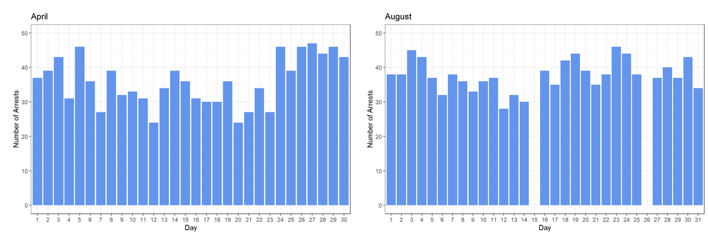

We next proceed to the months of October and November to see if liquor law violation arrests increase on Halloween or on the following day. We noted earlier that overall arrests spiked on November 1, and it would be reasonable to surmise that many of these arrests were related to alcohol. The following four graphs show arrest tallies for each day in October and November, the first two showing arrest tallies only for liquor law violation arrests, and the second two showing arrest tallies for all categories except liquor law violations.

##### Breakdown

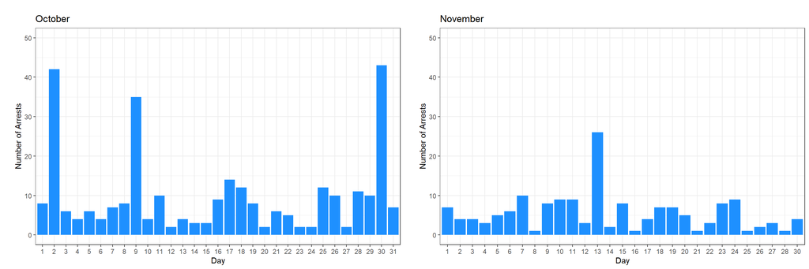

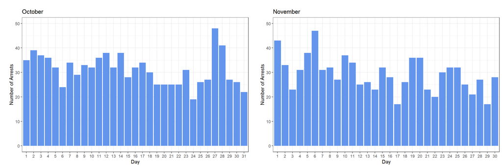

Surprisingly, there is no surge in liquor law arrests on either October 31 or November 1, meaning that the November 1 arrest peculiarity must be explained by an increase in some other category of arrest. However, the day before Halloween, October 30, saw over 40 liquor law arrests, a number which towers over the overall yearly trend of around 10 such arrests per day. Moreover, the three days with large arrest tallies in October are no different from the rest of the month when liquor law arrests are excluded.

In summary, arrests generally occur more often during the summer than during the winter. The months of April and August feature unusual trends at the ends of the months, with a larger than normal number of arrests occurring during these times. This effect is driven by a large increase in liquor law violation arrests, which occur during the bookend periods of the academic year at UNC. On a daily level, arrests drop precipitously around Christmas, while they increase on New Year’s Day and around Halloween. These trends suggest that arrest activity is not uniform across the year and that preconceived notions of arrest trends–such as their increase during the summer or on some holidays–are in fact realized in Chapel Hill.

#### Question 3

*Are there associations between types of arrests and the demographic information about the individual arrested? If the age, race, and gender of a person are known, could the person’s most likely arrest category be predicted?*

First, we provide a baseline summary of the demographic information for the people arrested in Chapel Hill between January 1, 2010 and August 26, 2019. The following two bar charts apportion the arrests in this time span by race and by gender, respectively, and display the number of arrests belonging to each race and gender category.

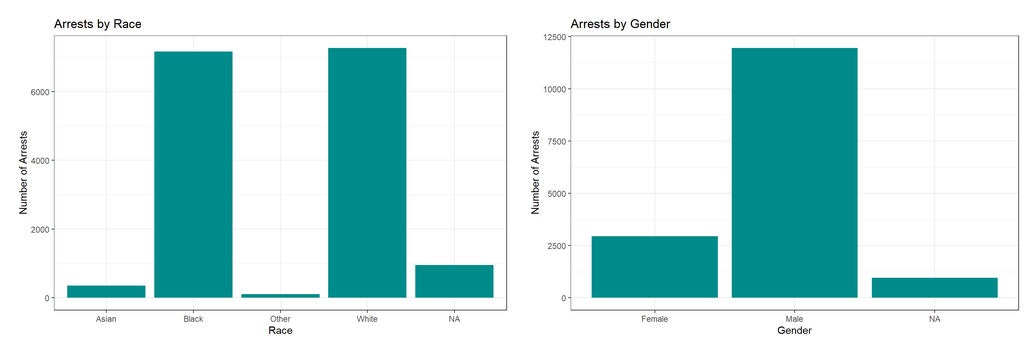

From these charts, the number of black people and the number of white people arrested were roughly equal, with few Asian people arrested. Roughly 1,000 arrestees did not have a race indicated. These figures stand in the face of the racial makeup of Chapel Hill, which, as of the 2010 Census, was 72.8 percent white and only 9.7 percent black. It should be noted that not all arrestees in Chapel Hill are residents of Chapel Hill, but nevertheless, a disproportionate number of people arrested were black. Moreover, approximately four times as many males were arrested as females, with again around 1,000 arrestees not having a gender indicated. Once more, arrests are not proportionate among gender lines.

We next analyze the distribution of the ages of people arrested in Chapel Hill. Below is a histogram displaying these ages.

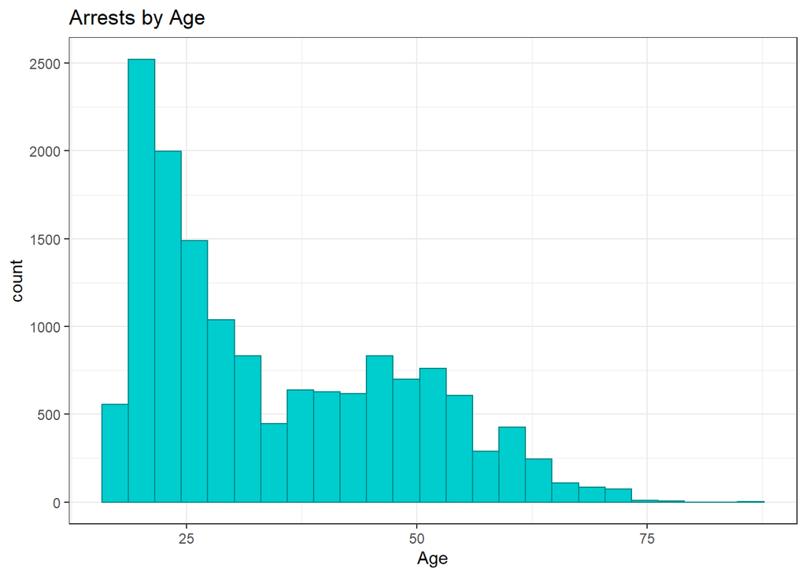

Two interesting trends appear above. First, the ages of the arrestees are skewed, with many more younger people arrested than middle-aged or older people. Second, the distribution appears bimodal, with one peak around age 20 and a second peak around age 50. The peak around age 50, however, is much smaller than that around age 20. Between these two ages, especially between ages 30 and 40, comparatively few people were arrested, and very few people older than age 60 were arrested. This distribution is not surprising in face of the fact that Chapel Hill is a college town, with a large population of students between the ages of 18 and 22. The age breakdown of the Chapel Hill population, per the 2010 Census, is detailed below.

```
## # A tibble: 4 x 3
##   `Age Range`       Population Arrested
##   <chr>             <chr>      <chr>
## 1 Between 18 and 24 38.1%      34.1%
## 2 Between 25 and 44 28.6%      38.2%
## 3 Between 45 and 64 22.3%      25.9%
## 4 65 and over       11.1%      1.9%
```

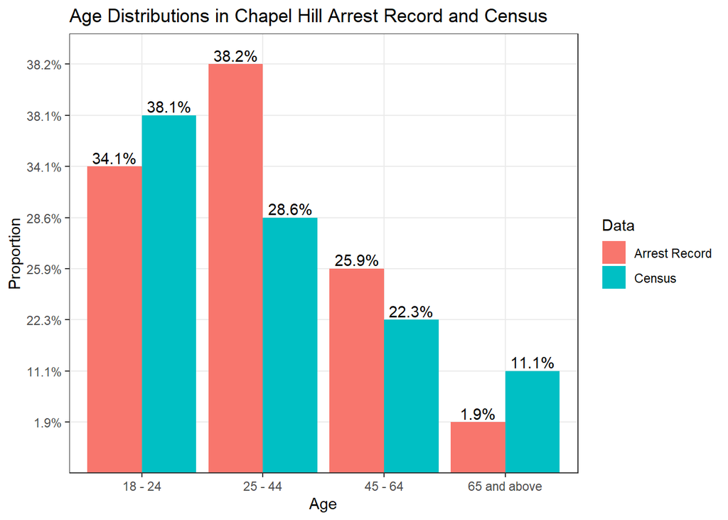

As can be seen above, despite the large number of young people arrested in the histogram, people between the ages of 18 and 24 were arrested slightly disproportionately less than their share of the population would suggest. Moreover, although it appears from the histogram that those between the ages of 25 and 44 did not represent as many arrests, they were arrested disproportionately more than their share of the population would suggest. Finally, those age 65 or older, who make up 11.1 percent of the over-18 population, represented only 1.9 percent of arrests.

Having analyzed the overall ages of the people arrested, we next consider whether certain arrest categories have different age distributions. The six histograms below display the age distribution for each of six arrest categories.

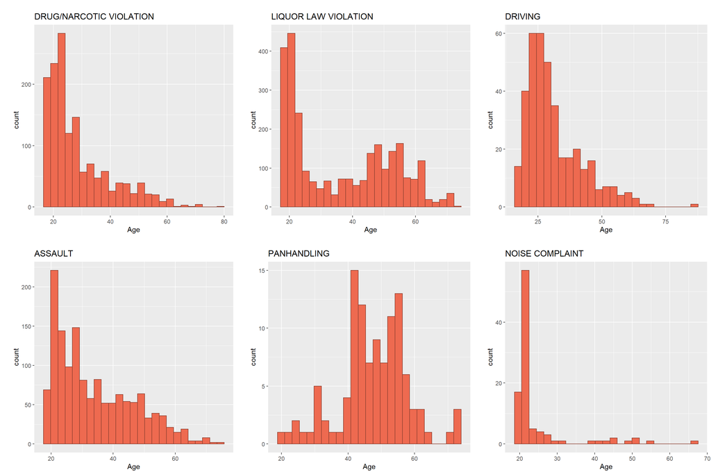

Evidently, the age distribution is not consistent across different arrest categories. Perhaps most striking of the above histograms is that for noise complaints. This distribution is heavily centralized around the traditional college ages, which follows from the fact that college students are most likely to throw loud parties for which a noise complaint would be received. On the other hand, the distribution of panhandling arrests is significantly different from the overall distribution, with a more unimodal shape centered around age 50. This result is logical, as panhandling is specifically unassociated with college students. The other distributions more closely follow the overall distribution of ages. Drug and narcotic violation arrests have a mode in the low twenties and then taper off as age increases. Liquor law violation arrests have a similar mode, but it also features a second, smaller mode around the age of 50. Driving violations and assaults are more centralized in the mid-20s but follow a similar tendency to taper off. Many of the other arrest categories not depicted above featured distributions similar to the overall distribution.

Next, we run a multinomial logistic regression model on the arrest dataset, attempting to predict the arrest category using the age, race, and gender of the person arrested as predictors. The code used to generate this model is displayed below. Before running the model, one primary adjustment was needed to the dataset. Several arrests did not provide the arrestee’s race, gender, or age. All such observations were discarded, as values for these three variables in all observations were needed to run the model. Furthermore, the other category was chosen as the reference level as a result of it representing nothing more than all arrests that did not fit into one of the other categories.

```r
arrests.2$Category2 <- relevel(arrests.2$Category, ref = "OTHER")
test <- multinom(Category2 ~ Age + Race + Gender, data = arrests.2, maxit = 500)
```

Having run the model, we interpret its results by considering the probability that each combination of race, gender, and age is arrested for each arrest category. Naturally, the probabilities for a single race, gender, and age combination across all arrest categories sum to one. The code below performs this step.

```r
dage <- data.frame(Race = rep(c("Black", "White"), each = 106), Gender = c(rep(c("Male", "Female"), each = 53), rep(c("Male", "Female"), each = 53)), Age = rep(c(18:70), 4))
pp.age <- cbind(dage, predict(test, newdata = dage, type = "probs", se = TRUE))
lpp <- melt(pp.age, id.vars = c("Race", "Gender", "Age"), value.name = "probability")
```

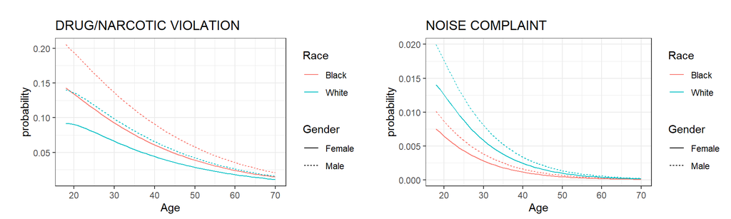

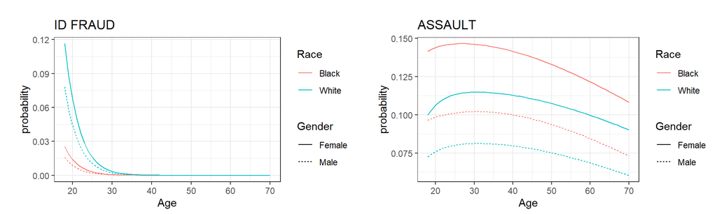

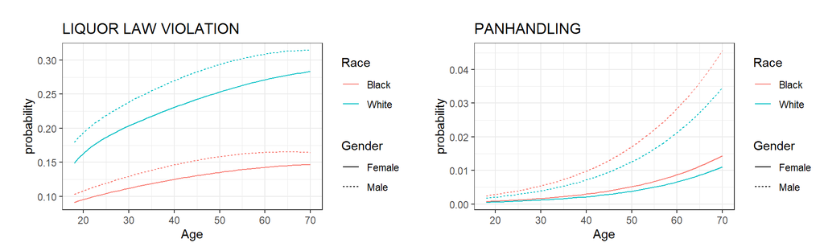

#### Question 4

*Are there areas in Chapel Hill that are more prone to arrests than others? If so, could these areas be classified into distinct clusters?*

```r
  factoextra::fviz_nbclust(df.CH, cluster::clara, diss = dMat.CH, method = "silhouette")
```

[output not shown]